# lab_5_Sokurenko

## Лабораторна робота №5. Алгоритми пошуку. Стратегія "грубої сили

Мета: Засвоїти варіанти реалізації алгоритмів пошуку засобами Python і методи оцінки їх складності.

Виконав Сокуренко Максим

Оцінити асимптотичну складність алгоритму лінійного пошуку у $О$-нотації.

```python
def linear_search(a_list, x):
    i, length = 0, len(a_list)
    while i < length and x != a_list[i]:
        i += 1
    return i+1 if i < length else -1


search_item = int(input("Введіть шуканий елемент: "))

a = [32, 1, 3, 4, 2, 1]
linear_search(a, search_item)
```

Асимптотична складність лінійного пошуку становить $O(n)$

- Оцінити асимптотичну складність алгоритму бінарного пошуку пошуку у $О$-нотації.

```python
def bin_search(a_list, x, left, right):
    if left > right or len(a_list) == 0:
        return -1
    middle = (left + right) // 2
    if a_list[middle] == x:
        return middle + 1
    elif (a_list[middle] < x):
        return bin_search(a_list, x, middle + 1, right)
    else: # a_list[middle] > x
        return bin_search(a_list, x, left, middle - 1)


a = range(7,21)
search_item = int(input("Введіть шуканий елемент: "))
bin_search(a, search_item, 0, len(a) - 1)
```

Час виконання бінарного пошуку зростає логарифмічно з розміром вхідних даних, і асимптотична складність становить $O(log(n))$

- написати функцію, яка б могла повертати датафрейм з наступним складом полів: ("n", "time"), де `n` -- розмір масиву для функції `linear_searh();

```python
import time

def linear_search(arr):
    start_time = time.time()
    end_time = time.time()
    return end_time - start_time

def generate_data(start_n, end_n, step):
    data = []
    for n in range(start_n, end_n + 1, step):
        arr = list(range(n))
        search_time = linear_search(arr)
        data.append((n, search_time))
    return data


start_n = 100
end_n = 500
step = 50
result_data = generate_data(start_n, end_n, step)
print(result_data)
```

```
[(100, 0.0), (150, 0.0), (200, 0.0), (250, 0.0), (300, 0.0), (350, 0.0), (400, 0.0), (450, 0.0), (500, 0.0)]
```

- написати функцію, яка б могла повертати датафрейм з наступним складом полів: ("n", "time"), де `n` -- розмір масиву для функції `bin_searh();

```python
import time

def binary_search(arr):
    start_time = time.time()
    end_time = time.time()
    return end_time - start_time

def generate_dataframe(start_n, end_n, step):
    data = []
    for n in range(start_n, end_n + 1, step):
        arr = list(range(n))
        search_time = binary_search(arr)
        data.append((n, search_time))
    return data

start_n = 100
end_n = 500
step = 50
result_data = generate_dataframe(start_n, end_n, step)
print(result_data)
```

```
[(100, 0.0), (150, 0.0), (200, 0.0), (250, 0.0), (300, 0.0), (350, 0.0), (400, 0.0), (450, 0.0), (500, 0.0)]
```

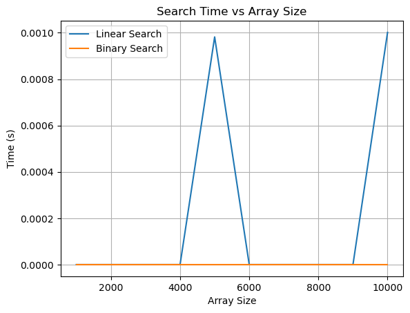

```python
import matplotlib.pyplot as plt
import time

def linear_search(arr, target):
    start_time = time.time()
    for i in range(len(arr)):
        if arr[i] == target:
            break
    else:
        i = -1
    end_time = time.time()
    return end_time - start_time

def binary_search(arr, target):
    start_time = time.time()
    low, high = 0, len(arr) - 1
    while low <= high:
        mid = (low + high) // 2
        if arr[mid] < target:
            low = mid + 1
        elif arr[mid] > target:
            high = mid - 1
        else:
            break
    else:
        mid = -1
    end_time = time.time()
    return end_time - start_time

def measure_search_time(search_func, array_sizes, target):
    times = []
    for size in array_sizes:
        arr = list(range(size))
        search_time = search_func(arr, target)
        times.append(search_time)
    return times

array_sizes = list(range(1000, 10001, 1000))  # Розміри масивів
target = array_sizes[-1] // 2  # Ціль для пошуку

linear_times = measure_search_time(linear_search, array_sizes, target)
binary_times = measure_search_time(binary_search, array_sizes, target)

plt.plot(array_sizes, linear_times, label='Linear Search')
plt.plot(array_sizes, binary_times, label='Binary Search')
plt.xlabel('Array Size')
plt.ylabel('Time (s)')
plt.title('Search Time vs Array Size')
plt.legend()
plt.grid(True)
plt.show()
```

## Контрольні запитання

1. Сформулювати задачу пошуку.

Знайти позицію (індекс) заданого елемента у структурі даних, наприклад, у масиві або списку.

Часова складність (асимптотична). Просторова складність. Простота реалізації. Стійкість до змін розміру даних. Працездатність на різних типах даних.

3. Що таке лінійний пошук і яка його асимптотична складність?

Перебір всіх елементів масиву послідовно до знаходження шуканого елемента або кінця масиву.

Асимптотична складність: $O(n)$.

4. Що таке бінарний (двійковий) пошук і в чому полягає його головний

принцип роботи?

Працює на відсортованому масиві, розділяючи діапазон пошуку навпіл і порівнюючи середній елемент із шуканим.

Головний принцип: Рекурсивне або ітеративне поділ масиву на дві частини до знаходження елемента або звуження діапазону до нуля.

5. Які переваги і недоліки використання бінарного пошуку порівняно з лінійним?

Переваги: Менша часова складність: $O(\log n)$. Ефективний для великих масивів.

Недоліки: Потребує відсортованого масиву. Складніший у реалізації порівняно з лінійним пошуком.

6. Які ще алгоритми пошуку існують, окрім лінійного і бінарного?

Інтерполяційний пошук Експоненціальний пошук Фібоначчі пошук Пошук у хеш-таблицях Пошук в деревоподібних структурах (наприклад, AVL-дерева, червоно-чорні дерева)